# **Çoklu Doğrusal Regresyon ile Maaş Tahmin Modeli**

[figure not shown]

Maaş bilgileri ve **1986** yılına ait kariyer istatistikleri paylaşılan beyzbol oyuncularının maaş tahminleri için bir doğrusal regresyon modeli geliştireceğiz.

**Veri Seti Hikayesi**

Bu veri seti orijinal olarak Carnegie Mellon Üniversitesi’nde bulunan StatLib kütüphanesinden alınmıştır.

Veri seti 1988 ASA Grafik Bölümü Poster Oturumu’nda kullanılan verilerin bir parçasıdır.

Maaş verileri orijinal olarak Sports Illustrated, 20 Nisan 1987’den alınmıştır.

1986 ve kariyer istatistikleri, Collier Books, Macmillan Publishing Company, New York tarafından yayınlanan 1987 Beyzbol Ansiklopedisi Güncellemesinden elde edilmiştir.

**Değişkenler**

*20 Değişken 322 Gözlem 21 KB*

- AtBat 1986-1987 sezonunda bir beyzbol sopası ile topa yapılan vuruş sayısı
- Hits 1986-1987 sezonundaki isabet sayısı
- HmRun 1986-1987 sezonundaki en değerli vuruş sayısı
- Runs 1986-1987 sezonunda takımına kazandırdığı sayı
- RBI Bir vurucunun vuruş yaptıgında koşu yaptırdığı oyuncu sayısı
- Walks Karşı oyuncuya yaptırılan hata sayısı
- Years Oyuncunun major liginde oynama süresi (sene)
- CAtBat Oyuncunun kariyeri boyunca topa vurma sayısı
- CHits Oyuncunun kariyeri boyunca yaptığı isabetli vuruş sayısı
- CHmRun Oyucunun kariyeri boyunca yaptığı en değerli sayısı
- CRuns Oyuncunun kariyeri boyunca takımına kazandırdığı sayı
- CRBI Oyuncunun kariyeri boyunca koşu yaptırdırdığı oyuncu sayısı
- CWalks Oyuncun kariyeri boyunca karşı oyuncuya yaptırdığı hata sayısı
- League Oyuncunun sezon sonuna kadar oynadığı ligi gösteren A ve N seviyelerine sahip bir faktör
- Division 1986 sonunda oyuncunun oynadığı pozisyonu gösteren E ve W seviyelerine sahip bir faktör
- PutOuts Oyun icinde takım arkadaşınla yardımlaşma
- Assits 1986-1987 sezonunda oyuncunun yaptığı asist sayısı
- Errors 1986-1987 sezonundaki oyuncunun hata sayısı
- Salary Oyuncunun 1986-1987 sezonunda aldığı maaş(bin uzerinden)
- NewLeague 1987 sezonunun başında oyuncunun ligini gösteren A ve N seviyelerine sahip bir faktör

**Verinin İçeri Aktarılması**

Verimizi ilgili klasörden içeri aktarıyor:

```
df <- read.csv("C:\\Users\\GLB90057874\\Desktop\\Denetimli İstatistik\\hitters_eda.csv")
```

*Veriye ilk bakış:*

[output not shown]

**Çoklu Doğrusal Regresyon Modelinin Tüm Değişkenler ile Kurulması: Base Model**

```
base_model=lm(Salary~., data=df)
```

Özetine ve ilgili katsayılarına bakalım.

```
summary(base_model)
```

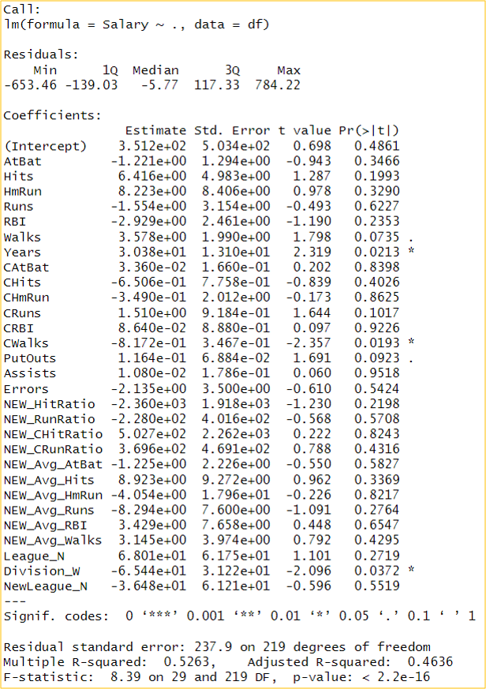

Model istatistiksel olarak anlamlıdır. **(F-istatistiği = 8.39, p-değeri < 2.2e-16).**

R-kare değeri **0.5263’tür,** bu da modelin Salary değişkenindeki varyasyonun **%52.63**’ünü açıkladığını gösterir. Düzeltilmiş R-kare değeri **0.4636**’dır, bu da modeldeki bağımsız değişkenlerin sayısını dikkate alır.

*VIF değerlerini inceleyelim:*

```
library(car)
vif(base_model) #VIF değerlerini yazdırır.
```

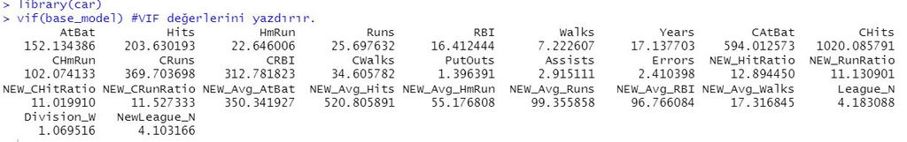

*Yüksek VIF (10’dan büyük):*

AtBat, Hits, CAtBat, CHits, NEW_Avg_AtBat, NEW_Avg_Hits: Bu değişkenlerin VIF değerleri nispeten yüksek, bu da bu değişkenler arasında potansiyel çoklu doğrusallık sorunları olduğunu gösteriyor. Bu, bu değişkenlerin birbirleriyle ilişkili olabileceği anlamına gelir ve bağımlı değişken üzerindeki etkilerini izole etmeyi zorlaştırabilir.

**WIF Değerlerine Göre Base_Model2’nin Kurulması**

Çoklu doğrusallıktan etkilenmemek adına ve daha iyi bir performans modeli için farklı bir model kuruyoruz.

Bu modelde WIF değerleri baz alınarak yeni üretilen değişkenler üzerinden kuracağız.

```
base_model2=lm(Salary~Walks+PutOuts+Assists+Errors+NEW_HitRatio+NEW_RunRatio+NEW_CHitRatio+NEW_CRunRatio+League_N+Division_W+NewLeague_N, data=df)

summary(base_model2)

vif(base_model2)
```

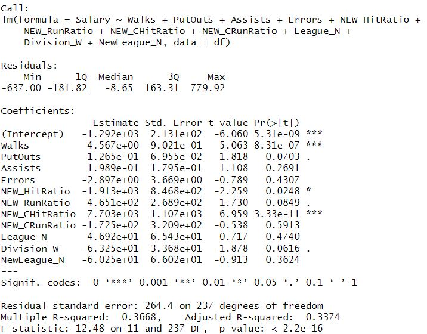

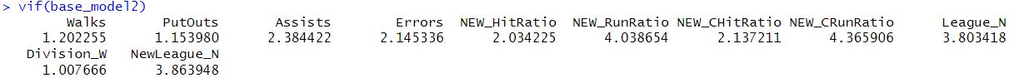

**Değişken Seçim Yöntemlerinin Kullanılması ve Model Değerlendirme**

```
library(olsrr)
library("ISLR")
library(car)

a=ols_step_all_possible(base_model2)
plot(a)
summary(a)
```

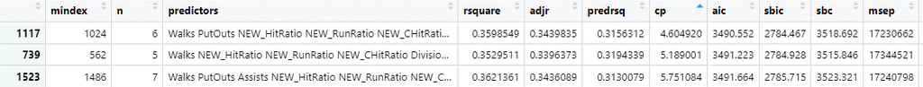

Cp değerlerine göre **1024** nolo modelde **Walks PutOuts NEW_HitRatio NEW_RunRatio NEW_CHitRatio Division_W N:6 CP:4.60** olarak çıkmıştır ve modeli en iyi açıklayan baz değişkenlerin bu şekilde olduğunu söyleyebiliriz.

```
s=ols_step_both_p(base_model2)
s=ols_step_both_p(base_model2, pent = 0.05, prem = 0.1)
s
s$base_model2
plot(s)
```

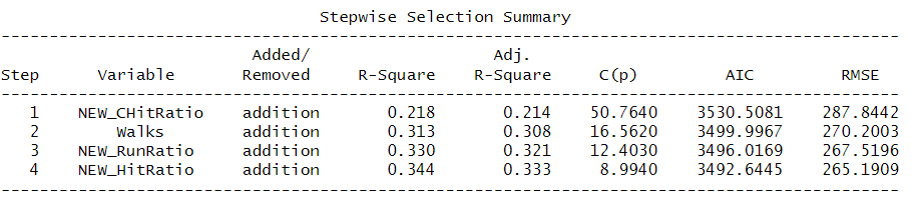

Stepwise yöntemi ile de seçim yaptığımızda R2 ve Düzeltimiş R2 değerleri özellikle 4 değişken içerisinde artış gösterdiğini görüyoruz.

**Base_Model3 Oluşturulması ve Matrix Plot Çizimi**

[output not shown]

```
base_model3df <- data.frame(df$Walks, df$Salary, df$PutOuts,df$NEW_HitRatio,df$NEW_RunRatio,df$NEW_CHitRatio,df$Division_W)
pairs(base_model3df, pch=19, col='red', lower.panel = NULL)
```

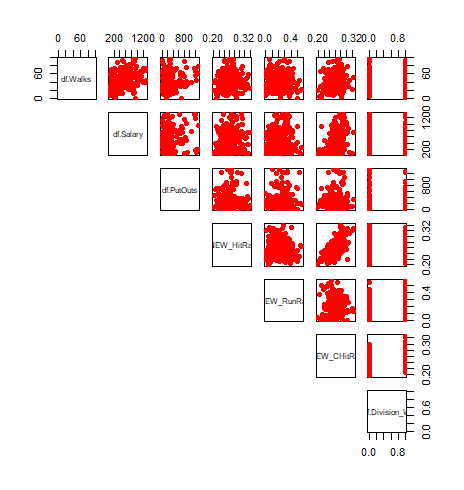

**Değişkenlerin Normalleştirilmesi için Dağılım Grafiklerinin Kontrolü**

[output not shown]

Değişkenler üzerinde istatiksel işlemler yapmadan önce dağılım grafiklerinin kontrolünü sağlıyoruz. Sayısal değişkenler üzerinde log dönüşümü yaparak modeli tekrar oluşturuyoruz.

```
log_transform_vars <- c("Walks", "PutOuts", "NEW_HitRatio", "NEW_RunRatio", "NEW_CHitRatio")
df[log_transform_vars] <- log(df[log_transform_vars] + 1)  # +1 eklenmesi log(0) hatasını önler

log_transform_model <- lm(Salary ~ Walks + PutOuts + NEW_HitRatio + NEW_RunRatio + NEW_CHitRatio + Division_W, data = df)

summary(log_transform_model)
```

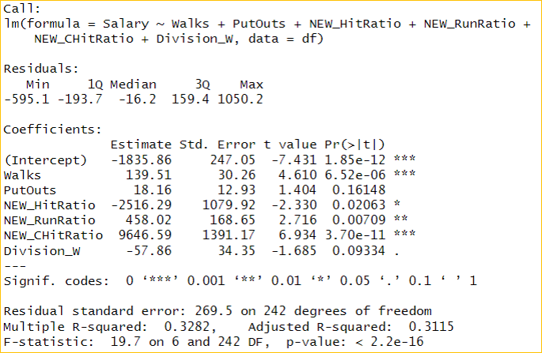

**Log Alınmış Model Matrix Plot Çizimi**

```
log_transform_modeldf <- data.frame(df$Walks, df$Salary, df$PutOuts,df$NEW_HitRatio,df$NEW_RunRatio,df$NEW_CHitRatio,df$Division_W)
pairs(log_transform_modeldf, pch=19, col='red', lower.panel = NULL)
```

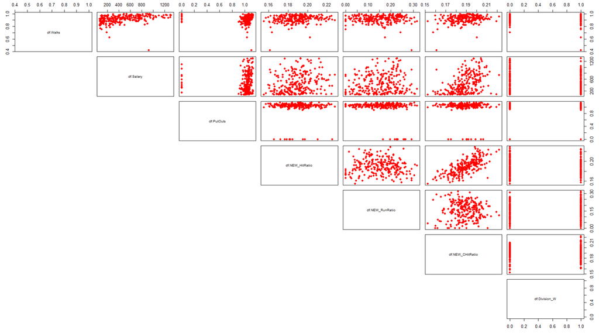

**Hataların Normal Dağıldığını Kontrol Etme**

```
qqnorm(log_transform_model$residuals)
qqline(log_transform_model$residuals)
```

[figure not shown]

**Kolmogorov-Smirnov Testi**

```
ks.test(log_transform_model$residuals, "pnorm")
```

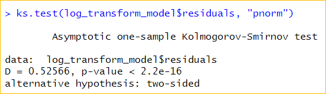

Bu test sonuçlarına göre, regresyon modelinizin hata terimleri normal bir dağılıma uymamaktadır. p değeri çok düşük olduğu için, null hipotez (veri setinin normal bir dağılıma sahip olduğu) reddedilir. Bu durumda, modelinizin normalite varsayımı karşılamadığını söyleyebiliriz.

**Hataların Sabit Varyanslı Olup Olmadığını Kontrolü**

Hataların standartlaştırılmış (Studentized) değerlerini elde etmek için

```
log_transform_model_stand_residuals <- rstandard(log_transform_model)
```

Hataların standartlaştırılmış değerlerini görselleştirmek için

```
plot(log_transform_model_stand_residuals, ylab = "Standartlaştırılmış Hatalar", xlab = "Gözlemler")
abline(h = 0, col = "red", lty = 2)
```

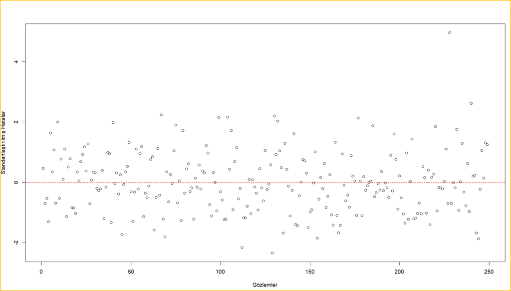

Residual plot çizimi

```
plot(log_transform_model, which = 1)
```

[figure not shown]

**Uç Değer ve Etkin Gözlem Kontrolü**

Cook’s Distance hesaplanması:

```
cooksd <- cooks.distance(log_transform_model)
```

Cook’s Distance grafikle görselleştirme

```
plot(cooksd, pch = "o", cex = 1, main = "Cook's Distance")
abline(h = 4/length(log_transform_model$residuals), col = "red", lty = 2)
```

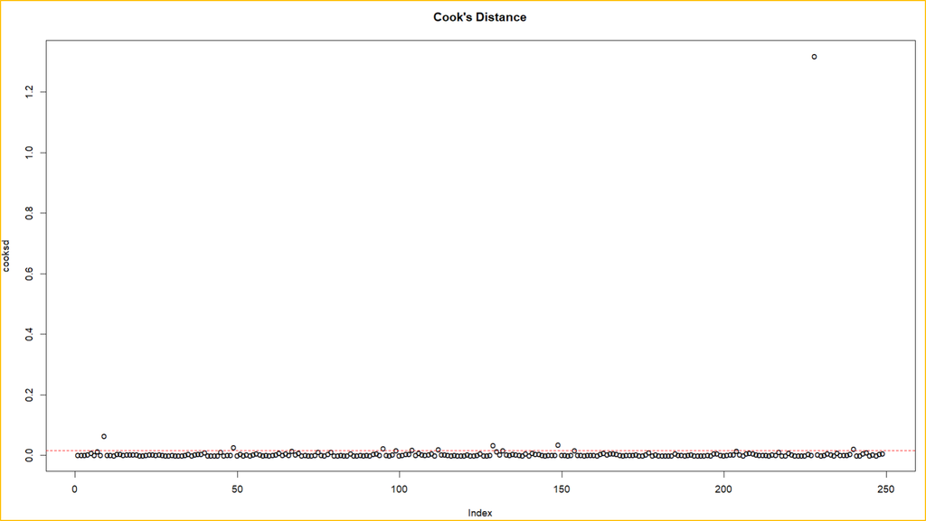

Residuals vs. Leverage grafik

```
par(mfrow = c(1, 1))
plot(log_transform_model, which = 5)
```

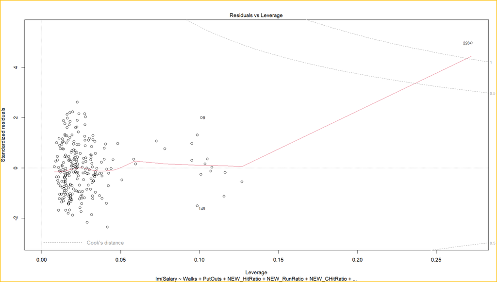

**VIF Değer Kontrolü**

```
vif(log_transform_model)
```

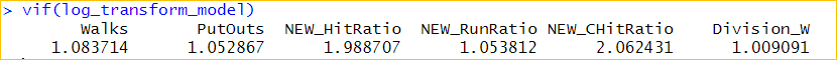

**Final Model Katsayıları**

```
summary(log_transform_model)
```

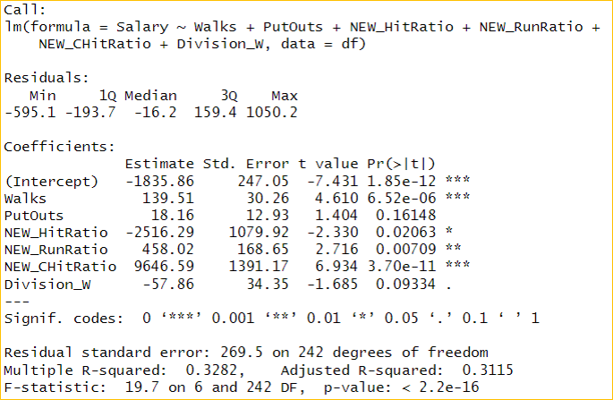

**Katsayıların %95’lik Güven Aralıklarını Elde Etmek**

Güven ve Tahmin Aralıkları

```
confint(log_transform_model)
confint(log_transform_model,level=0.95)
```

[figure not shown]

**Yeni Bir Gözlem Değeri için %95’lik Güven Aralığını ve Kestirim Aralığını Oluşturma**

Walks + PutOuts + NEW_HitRatio + NEW_RunRatio + NEW_CHitRatio + Division_W

*Yeni gözlem değeri için 95% güven aralığı*

```
new_observation <- data.frame(Walks = 0.99,
                              PutOuts = 1.11,
                              NEW_HitRatio = 0.20,
                              NEW_RunRatio = 0.29,
                              NEW_CHitRatio = 0.20,
                              Division_W = 1)
predict_interval <- predict(log_transform_model, newdata = new_observation, interval = "confidence", level = 0.95)
```

```
cat("95% Güven Aralığı:", predict_interval[1], "ile", predict_interval[2], "\n")
```

[figure not shown]

*Yeni gözlem değeri için tahmin ve 95% kestirim aralığı*

```
predict_interval <- predict(log_transform_model, newdata = new_observation, interval = "prediction", level = 0.95)
```

[output not shown]

**Model’i Geliştirmek Üzere Görüş ve Öneriler**

- Modeldeki yeni türetilen ve mevcut değişkenler gözden geçirebilir, analize düşük, korelasyonu yüksek değişkenler çıkarılabilir.
- Değişkenlere uygulanan dönüşümleri gözden geçirebiliriz. Belki de farklı dönüşümler veya ölçeklemeler kullanarak modelin performansını artırabiliriz.
- Bağımsız değişkenler arasındaki çoklu doğrusallığı kontrol ettikten sonra bu değişkenlerde dönüşümler ya da farklı ölçeklemeler ile kontrol sağlayabiliriz.
- Veri setini genişletmeli, mümkünse daha çok gözlem değeri elde etmeliyiz.
- Tüm değişkenler ile kurulan modelden sonrasında değişken seçimi yapmalı ve sonrasında değişimler ve dönüşümler uygulamalıyız.